# boosting

### Statistique de base

##### 1. Proportions de spam

On charge la librairie kernlab nous permetttant de charger le jeu de donnée spam

```r
library(kernlab)
data("spam")
```

**Determination des proportions.** On commence donc par determiner le nombre de spams (donc de non_spam egalement ).

```r
set.seed(9146301)
ytable <- table(spam$type)
ytable
```

```
##
## nonspam    spam
##    2788    1813
```

Vu que la commande dim(spam)[1] nous retourne la dimension du jeu de données, on divise les nombres de spam puis de non spam par cette valeur pour avoir un ratio

```r
ratio_non_spam = ytable[1]/dim(spam)[1]
ratio_spam = ytable[2]/dim(spam)[1]
cbind(ratio_spam,ratio_non_spam)
```

```
##      ratio_spam ratio_non_spam
## spam  0.3940448      0.6059552
```

**On a donc 40% de spam**

*Quel est le taux d’erreur du classifieur constant qui pourrait servir de reference?*

La proportion de non_spam est plus élévé que celle des spams. En prédisant tout le temps qu’on a des non spams, on aurait **une précision de 60%**. **On pourrait donc se servir du classifieur constant de non_spam**

##### 2. train_test split 80-20

On separe notre jeu de données en deux : le train comportera 80% de notre jeu de données et le test 20%. On va essayer de conserver les differentes proportions du passage du train au test.

```r
library(caTools)
set.seed(111)

index <- sample.split(spam$type, SplitRatio = 0.80)

# Construction du train  et du test
spam.app = subset(spam,index == TRUE)
spam.test = subset(spam , index == FALSE)
```

**Verification de la conservation des proportions :**

```r
b <- table(spam.app$type)
c <- table(spam.test$type)

ratio_spam_app = b[2]/dim(spam.app)[1]
ratio_spam_test = c[2]/dim(spam.test)[1]
cbind(ratio_spam_app,ratio_spam_test)
```

```
##      ratio_spam_app ratio_spam_test
## spam      0.3940217       0.3941368
```

A des virgules près on a quasiment les mêmes propotions qu’on peut arrondir à 40%.

### 3. Utilisation de Adaboost

On commence par charger la librairie Adaboost

```r
library(fastAdaboost)
```

##### 3.1 Entrainement d’Adaboost

Pour l’entrainement d’adaboost, on lui fournit : ** le type de variable à predire le jeu de données d’entrainement Les 10 iterations demandées dans l’énoncé **

```r
ada = adaboost(type~.,data = spam.app,nIter = 10)
```

**Evaluation des perfomances : erreur de train et de test**

```r
predictApp = predict(ada,newdata =spam.app)
predictTest = predict(ada,newdata=spam.test)
cbind(predictApp$error,predictTest$error)
```

```
##              [,1]      [,2]
## [1,] 0.0005434783 0.0597177
```

L’erreur d’apprentissage est quasi nulle sur le jeu d’apprentissage. Par contre, il se trompe dans 5.9% des cas sur le jeu de test.

##### 4. Courbe d’evolution par iteration des erreurs en apprentissage et en test

```r
index_Global = vector()
stackErrApp = vector()
stackErrTest = vector()
maxIter = 20

for (i in 1:20) {

  ada = adaboost(type~., spam.app , i)

  index_Global = cbind(index_Global,i) # L'index
  stackErrApp= cbind(stackErrApp,(predict(ada,newdata =spam.app))$error) # L'erreur correspondante
  stackErrTest= cbind(stackErrTest,(predict(ada,newdata =spam.test))$error)

}

for (i in 2:5) {
  ada = adaboost(type~., spam.app , maxIter*i)

  index_Global = cbind(index_Global,maxIter*i) # L'index
  stackErrApp= cbind(stackErrApp,(predict(ada,newdata =spam.app))$error) # L'erreur correspondante
  stackErrTest= cbind(stackErrTest,(predict(ada,newdata =spam.test))$error)

}
```

On affiche la courbe :

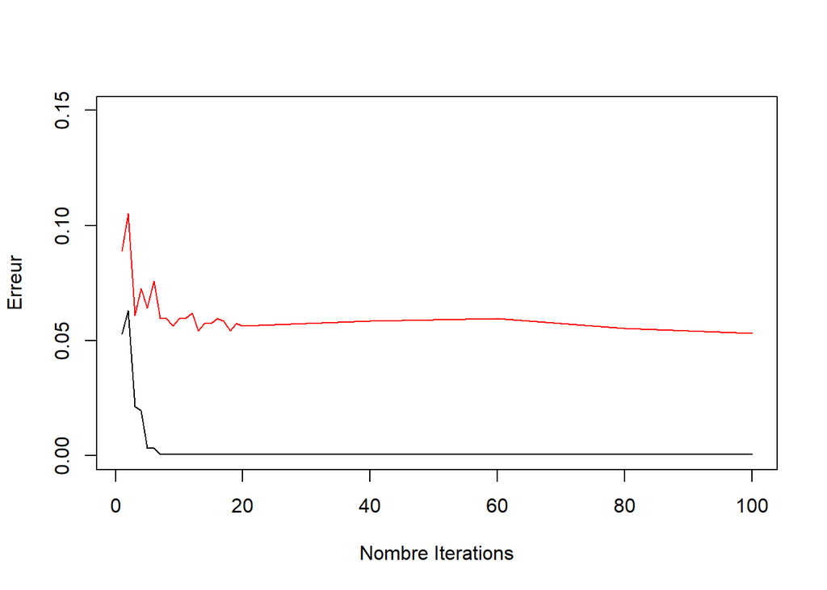

```r
plot(x = index_Global,y = stackErrApp[1,],type = 'l',ylab = 'Erreur' , col = 'black', xlab = 'Nombre Iterations',ylim = c(0,0.15))
lines(x = index_Global,y = stackErrTest[1,],type ='l',col = 'red')
legend( 1,legend=c("Apprentissage", "Test"),col=c("black", "red"), lty=1:2, cex=0.8)
```

Aussi bien en apprentissage qu’en test , on voit que pour de faibles iterations(i < 5), l’erreur est forte et augmente, avant de commencer à diminuer. Au bout de la 15-17e iteration, on ne gagne presque plus rien en test. A ce moment là, au niveau du jeu d’apprentissage, l’erreur est quasi nulle et n’évolue plus. Augmentez le nombre d’itération à très peu d’interet. De notre point de vue, le nombre optimal se trouve dans cet interval [15,17].